# base R vs the tidyverse

Stephen Roecker

2017-11-14

## Abstract

There are now 2 distinct dialects of the R programming language in the wild. The first and original dialect is typically referred to as “base” R, which derives from the base R package that comes pre-loaded as part of the standard R installation. The second, is known as the [“tidyverse”](https://www.tidyverse.org/) (or affectionately “Hadleyverse”) was largely developed by Hadley Wickham, one of R’s most prolific R package contributors. The tidyverse is an ‘opinionated’ collection of R packages that duplicate and seek to improve upon numerous base R functions for data manipulation (e.g. dplyr) and graphing (e.g. ggplot2). As the tidyverse has grown increasing more comprehensive, it has been suggested that it be taught first to new R users. The debate between which R dialect is better has generated a lot of heat, but not much light. This talk will review the similarities (with numerous examples) between the 2 dialects and hopefully help give new and old R users some perspective.

**Base R** - base R is more closely associated with “Statistics”, with focus on **statistical methods** not data manipulation methods - variable syntax - multiple ways to accomplish the same thing - the vector is probably the primary object - lots of [books](https://www.r-project.org/doc/bib/R-books.html) and [examples](https://www.statmethods.net/index.html), but fewer [free books](https://en.wikibooks.org/wiki/R_Programming)

**Tidyverse** - tidyverse more closely associated with “Data Science”, with focus on **data manipulation** methods - consistent synatx - fewer ways to accomplish the same thing - the data.frame is the primary object - lots of [free books](https://bookdown.org/)[(e.g. R for Data Science)](http://r4ds.had.co.nz/) and [examples](https://www.rstudio.com/resources/cheatsheets/) of tidyverse

## Load Packages

```r
library(aqp)
```

```r
library(soilDB) # install from github
library(lattice)
library(tidyverse) # includes: dplyr, tidyr, ggplot2, etc...
```

## Toy Soil Dataset

```r
# soil data for Marion County
s <- get_component_from_SDA(WHERE = "compname IN ('Miami', 'Crosby') AND majcompflag = 'Yes' AND areasymbol != 'US'")
```

```
## single result set, returning a data.frame
```

```r
h1 <- get_chorizon_from_SDA(WHERE = "compname IN ('Miami', 'Crosby')")
```

```
## single result set, returning a data.frame
```

```r
source("https://raw.githubusercontent.com/ncss-tech/soilReports/master/inst/reports/region11/lab_summary_by_taxonname/genhz_rules/Miami_rules.R")

h <- subset(h1, cokey %in% s$cokey & !grepl("H", hzname))
h$genhz <- generalize.hz(h$hzname, new = ghr$n, pat = ghr$p)
names(h) <- gsub("total", "", names(h))
h2 <- h

h <- merge(h, s[c("cokey", "compname")], by = "cokey", all.x = TRUE)

depths(h2) <- cokey ~ hzdept_r + hzdepb_r
site(h2) <- s

# examine dataset

str(h, 2)
```

```
## 'data.frame':    1376 obs. of  32 variables:
##  $ cokey      : int  14880219 14880219 14880219 14880222 14880222 14880222 14880223 14880223 14880223 14880225 ...
##  $ hzname     : chr  "Ap" "BE,Bt1,Bt2" "C" "Ap" ...
##  $ hzdept_r   : int  0 23 79 0 23 79 0 23 79 0 ...
##  $ hzdepb_r   : int  23 79 152 23 79 152 23 79 152 23 ...
##  $ texture    : Factor w/ 21 levels "cos","s","fs",..: 13 17 13 14 17 13 14 17 13 14 ...
##  $ sand_l     : num  NA NA NA NA NA NA NA NA NA NA ...
##  $ sand_r     : num  37 21 33 18 21 33 18 21 33 18 ...
##  $ sand_h     : num  NA NA NA NA NA NA NA NA NA NA ...
##  $ silt_l     : num  NA NA NA NA NA NA NA NA NA NA ...
##  $ silt_r     : num  49 43 47 64 43 47 64 43 47 64 ...
##  $ silt_h     : num  NA NA NA NA NA NA NA NA NA NA ...
##  $ clay_l     : num  11 27 15 15 27 15 15 27 15 15 ...
##  $ clay_r     : num  14 36 20 18 36 20 18 36 20 18 ...
##  $ clay_h     : num  25 40 25 25 40 25 25 40 25 25 ...
```

[output cut: 18 more lines]

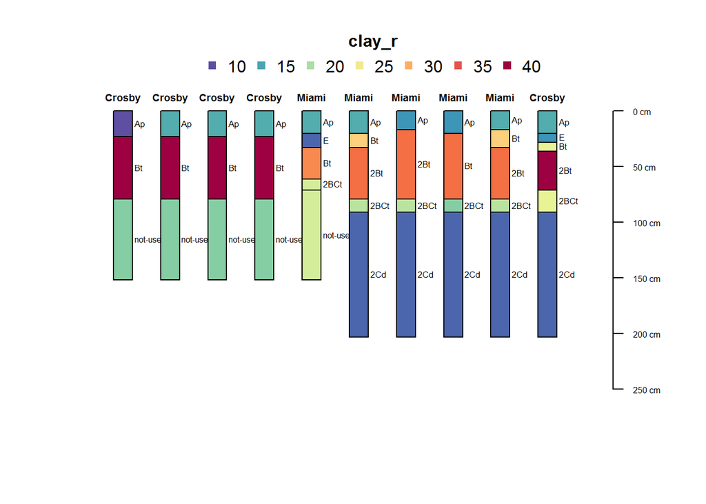

```r
# plot dataset

plot(h2[1:10], label = "compname", name = "genhz", color = "clay_r")
```